# Missing Stock Price

# Step 2: Piecewise Polynomial Interpolation

**We see that a ridge regression model is not suitable for predicting the missing labels.**

**If we take out the regularization term (alpha term), ridge regression simply becomes a polynomial regression. However, in order to fit the data well, we might need a high-order polynomial term. The drawback is, if it is linear term, then we get 0 turning point between two points. If it is a quadratic term, then we get 1 turning point（a parabola) between two points. If it is a cubic term, we get two turning points..... It is called an oscillation, or polynomial wiggle. It will overfit the data and will make the missing point inaccurately predicted between the two points.**

**We need to think about a piecewise polynomial interpolation model. What itdoes is that it gets rid of the polynomial wiggle by adding constraints and forcing adjacent points to have the same first and second derivatives (the slope). It will make the line between two points smoother and might be a good way to predict the missing labels between two points.**

**Let's try.**

```python
#use UnivariateSpline function in python. interpld function is also okay.

def Evaluate_spline_fitpack(training_feature, training_label, testing_feature, testing_label, total_label, number, S=None):

    model = interpolate.UnivariateSpline(training_feature, training_label, s=S)
    predicting_label = []

    if number in [0,1]:
        n = 250
    else:
        n = 146

    for each_feature in testing_feature:

        predicting_label.append(model(each_feature))

    x = np.arange(1,21,1)
    plt.subplot(2,1,1)
    plt.plot( x, predicting_label, x, testing_label,linewidth=4)
    plt.legend(['predicting_label'+str(number), 'testing_label'+str(number)], loc='lower left')
    plt.xticks(np.arange(1, 21, 1))

    i = np.linspace(0, n, num=500, endpoint=False)
    j = np.linspace(0, n, num=n, endpoint=False)
    plt.subplot(2,1,2)
    plt.plot( j, total_label,'go', i, model(i),'r', linewidth=1)
    plt.legend(['all_label'+str(number), 'predicting_line'+str(number)], loc='lower left')


    d = 0
    for i in range(20):
        d+=(abs(testing_label[i]-predicting_label[i])/testing_label[i])*100
    d/=20
    plt.show()

    return d
```

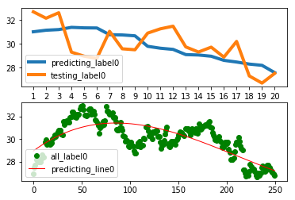

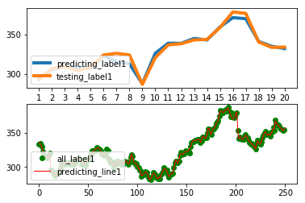

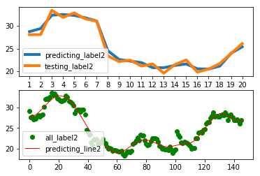

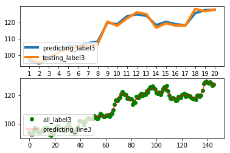

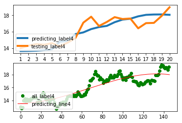

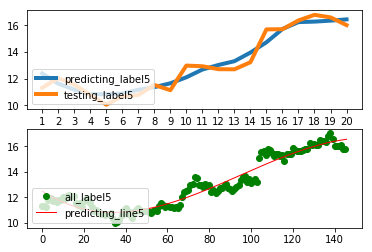

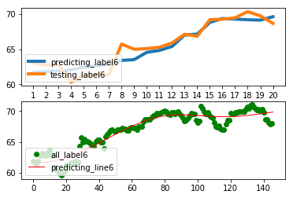

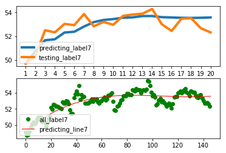

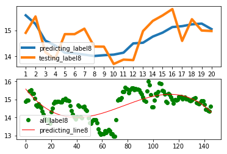

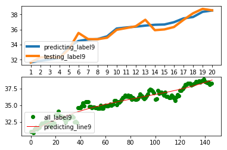

```python
d0 = Evaluate_spline_fitpack(training_feature0, training_label0, testing_feature0, testing_label0, total_label0, 0)
d1 = Evaluate_spline_fitpack(training_feature1, training_label1, testing_feature1, testing_label1, total_label1,1)
d2 = Evaluate_spline_fitpack(training_feature2, training_label2, testing_feature2, testing_label2, total_label2,2)
d3 = Evaluate_spline_fitpack(training_feature3, training_label3, testing_feature3, testing_label3, total_label3,3)
d4 = Evaluate_spline_fitpack(training_feature4, training_label4, testing_feature4, testing_label4, total_label4,4)
d5 = Evaluate_spline_fitpack(training_feature5, training_label5, testing_feature5, testing_label5, total_label5,5)
d6 = Evaluate_spline_fitpack(training_feature6, training_label6, testing_feature6, testing_label6, total_label6,6)
d7 = Evaluate_spline_fitpack(training_feature7, training_label7, testing_feature7, testing_label7, total_label7,7)
d8 = Evaluate_spline_fitpack(training_feature8, training_label8, testing_feature8, testing_label8, total_label8,8)
d9 = Evaluate_spline_fitpack(training_feature9, training_label9, testing_feature9, testing_label9, total_label9,9)
```

```python
d_avg = (d0+d1+d2+d3+d4+d5+d6+d7+d8+d9)/10
score = 50 * max(2 - d_avg, 0)
print('The score when s=None is: {0}'.format(score))
```

```
The score when s=None is: 0
```

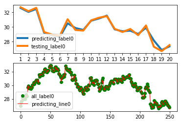

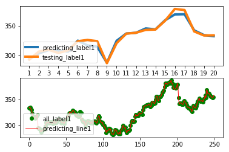

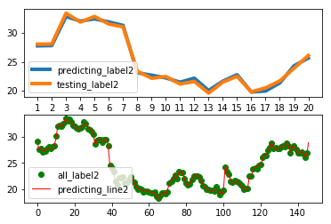

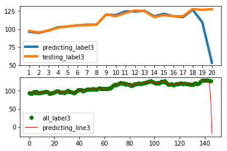

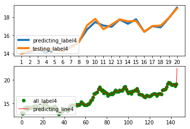

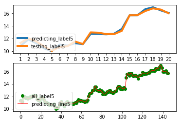

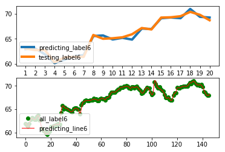

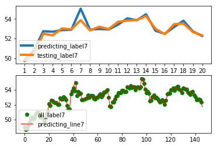

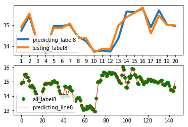

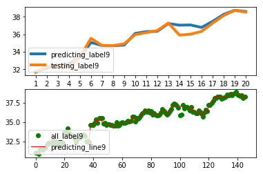

```python
d0 = Evaluate_spline_fitpack(training_feature0, training_label0, testing_feature0, testing_label0, total_label0, 0, 1)
d1 = Evaluate_spline_fitpack(training_feature1, training_label1, testing_feature1, testing_label1, total_label1,1,1)
d2 = Evaluate_spline_fitpack(training_feature2, training_label2, testing_feature2, testing_label2, total_label2,2,1)
d3 = Evaluate_spline_fitpack(training_feature3, training_label3, testing_feature3, testing_label3, total_label3,3,1)
d4 = Evaluate_spline_fitpack(training_feature4, training_label4, testing_feature4, testing_label4, total_label4,4,1)
d5 = Evaluate_spline_fitpack(training_feature5, training_label5, testing_feature5, testing_label5, total_label5,5,1)
d6 = Evaluate_spline_fitpack(training_feature6, training_label6, testing_feature6, testing_label6, total_label6,6,1)
d7 = Evaluate_spline_fitpack(training_feature7, training_label7, testing_feature7, testing_label7, total_label7,7,1)
d8 = Evaluate_spline_fitpack(training_feature8, training_label8, testing_feature8, testing_label8, total_label8,8,1)
d9 = Evaluate_spline_fitpack(training_feature9, training_label9, testing_feature9, testing_label9, total_label9,9,1)
```

```python
d_avg = (d0+d1+d2+d3+d4+d5+d6+d7+d8+d9)/10
score = 50 * max(2 - d_avg, 0)
print('The score when s=1 is: {0}'.format(score))
```

```
The score when s=1 is: 39.10268947575162
```

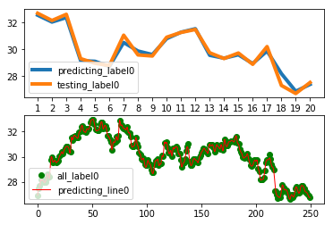

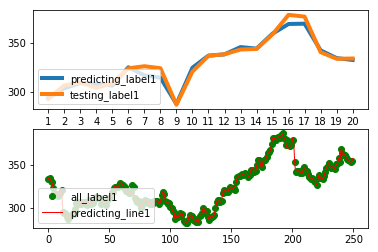

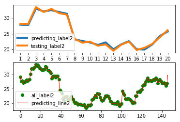

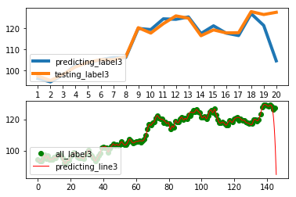

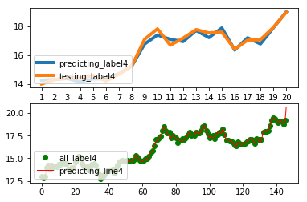

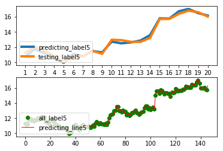

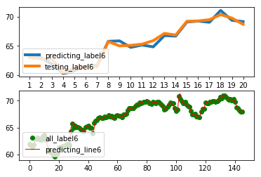

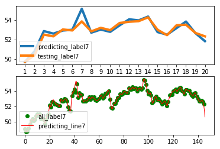

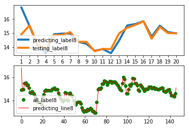

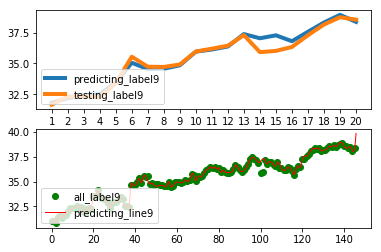

```python
d0 = Evaluate_spline_fitpack(training_feature0, training_label0, testing_feature0, testing_label0, total_label0, 0, 0)
d1 = Evaluate_spline_fitpack(training_feature1, training_label1, testing_feature1, testing_label1, total_label1,1,0)
d2 = Evaluate_spline_fitpack(training_feature2, training_label2, testing_feature2, testing_label2, total_label2,2,0)
d3 = Evaluate_spline_fitpack(training_feature3, training_label3, testing_feature3, testing_label3, total_label3,3,0)
d4 = Evaluate_spline_fitpack(training_feature4, training_label4, testing_feature4, testing_label4, total_label4,4,0)
d5 = Evaluate_spline_fitpack(training_feature5, training_label5, testing_feature5, testing_label5, total_label5,5,0)
d6 = Evaluate_spline_fitpack(training_feature6, training_label6, testing_feature6, testing_label6, total_label6,6,0)
d7 = Evaluate_spline_fitpack(training_feature7, training_label7, testing_feature7, testing_label7, total_label7,7,0)
d8 = Evaluate_spline_fitpack(training_feature8, training_label8, testing_feature8, testing_label8, total_label8,8,0)
d9 = Evaluate_spline_fitpack(training_feature9, training_label9, testing_feature9, testing_label9, total_label9,9,0)
```

```python
d_avg = (d0+d1+d2+d3+d4+d5+d6+d7+d8+d9)/10
score = 50 * max(2 - d_avg, 0)
print('The score when s=0 is: {0}'.format(score))
```

```
The score when s=0 is: 45.94535982995678
```

**In python, there are two more packages called interpolate.interp1d and interpolate.cubicspline. They do not use FITPACK to automatically select the best number of knots. Instead they just fit the curve by using the whole data. Let's try interp1d!**

```python
def Evaluate_spline_interp1d(training_feature, training_label, testing_feature, testing_label, total_label, number, S=None):

    model = interpolate.interp1d(training_feature, training_label, 'cubic',fill_value = 'extrapolate')
    predicting_label = []


    for each_feature in testing_feature:

        predicting_label.append(model(each_feature))




    d = 0
    for i in range(len(testing_feature)):
        d+=(abs(testing_label[i]-predicting_label[i])/testing_label[i])*100
    d/=len(testing_feature)
    n_1 = len(testing_feature)
    n_2 = len(total_label)

    x = np.arange(1,n_1+1,1)
    plt.subplot(2,1,1)
    plt.plot( x, predicting_label,x, testing_label,linewidth=4)
    plt.legend(['predicting_label'+str(number), 'testing_label'+str(number)], loc='lower left')
    plt.xticks(np.arange(1, n_1+1, 1))

    i = np.linspace(0, n_2, num=500, endpoint=False)
    j = np.linspace(0, n_2, num=n_2, endpoint=False)
    plt.subplot(2,1,2)
    plt.plot( j, total_label,'go', i, model(i),'r', linewidth=1)
    plt.legend(['all_label'+str(number), 'predicting_line'+str(number)], loc='lower left')

    plt.show()

    return d, len(testing_label)
```

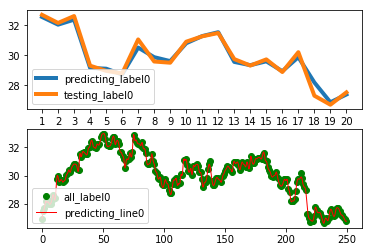

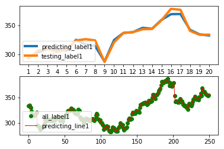

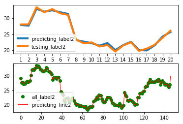

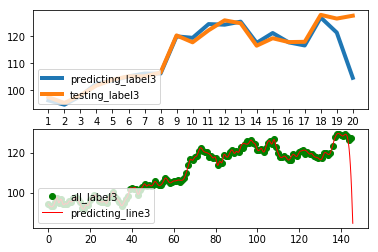

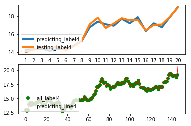

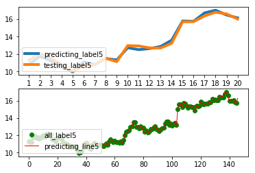

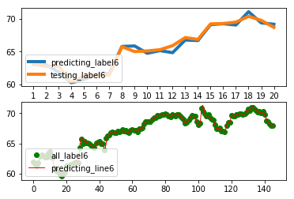

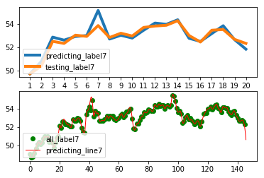

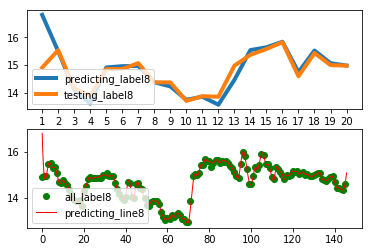

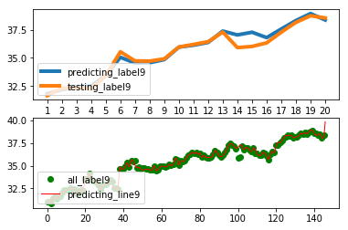

```python
dd0, nn0 = Evaluate_spline_interp1d(training_feature0, training_label0, testing_feature0, testing_label0, total_label0, 0, 0)
dd1, nn1 = Evaluate_spline_interp1d(training_feature1, training_label1, testing_feature1, testing_label1, total_label1,1,0)
dd2, nn2 = Evaluate_spline_interp1d(training_feature2, training_label2, testing_feature2, testing_label2, total_label2,2,0)
dd3, nn3 = Evaluate_spline_interp1d(training_feature3, training_label3, testing_feature3, testing_label3, total_label3,3,0)
dd4, nn4 = Evaluate_spline_interp1d(training_feature4, training_label4, testing_feature4, testing_label4, total_label4,4,0)
dd5, nn5 = Evaluate_spline_interp1d(training_feature5, training_label5, testing_feature5, testing_label5, total_label5,5,0)
dd6, nn6 = Evaluate_spline_interp1d(training_feature6, training_label6, testing_feature6, testing_label6, total_label6,6,0)
dd7, nn7 = Evaluate_spline_interp1d(training_feature7, training_label7, testing_feature7, testing_label7, total_label7,7,0)
dd8, nn8 = Evaluate_spline_interp1d(training_feature8, training_label8, testing_feature8, testing_label8, total_label8,8,0)
dd9, nn9 = Evaluate_spline_interp1d(training_feature9, training_label9, testing_feature9, testing_label9, total_label9,9,0)
```

```python
d_avg = (dd0+dd1+dd2+dd3+dd4+dd5+dd6+dd7+dd8+dd9)/10
score = 50 * max(2 - d_avg, 0)
print('The score when s=0 is: {0}'.format(score))
```

```
The score when s=0 is: 45.94535982995698
```

**I tried several piecewise polynomial interpolation models.**

**From the figures above, it is easy to see that by using the spline models, the score has been dramatically increased. The fitted lines are much closer to the actual data points. It is a suitable model for interpolating the inner missing labels when the outer points are known.**

**By trying several parameters S (positive smoothing factor) and set k(degree of smoothing)=cubic, I find the score is almost 46.**

**However, the model still has several problems so that it cannot be applied at this time.**

**Problem 1: The parameter S of the model determines the sensitivity of the fitting line, by choosing different S values, the results can be largely different, from 0 to 45. Although I used the true values of the missing labels to score the model, it is obvious that we cannot know the missing labels to select a suitable parameter S.**

**Problem 2: For some of the cases (such as case 0, case 1, and case 2), when choosing suitable parameter S, the fitted lines almost predict every single missing label with very high accuracy. However, for some other cases (such as case 7 and case 8), when the stock prices are highly fluctuating, using the same parameter S will not be suitable for those cases.**

**Problem 3: It is easy to find that while the spline model is accurate to predict the inner points, it has poor performance for predicting the outer points. In other words, it is good for interpolation, but bad for extrapolation. We can see that in case 3 and case 8, when there are only one or two points that need to be extrapolated, the spline model has low accuracy for those missing labels outside the non-missing labels.**

# Step 3: Sets of Piecewise Polynomial Interpolation Models

**Let's start by addressing problem 1 and problem 2 first.**

**Let's recall that what the model does is that it uses the non-missing labels in a particular case to train the model, and then predicts the missing labels within the same case.**

**It is often true that in stock market, for different stocks, the magnitudes, variations, and trends vary largely. It may not be correct to apply the same model to fit different data. Therefore, it will be better to train different models for different data sets and apply them separately.**

**We need to add the training-validation framework into the model.**

**Now focus on the interpolation only.**

**We can build a new function to separate the data into two parts depending on whether they are the data for interpolation or the data for extrapolation.**

```python
#new extracting function to separate the outer missing data and inner missing data

def Extract_values_new(number):

    i=-1
    prices = []
    training_feature = []
    training_label = []
    testing_feature = []
    testing_label = []
    total_label = []
    with open("C:/case/input/input0"+str(number)+".txt",'r') as file:
        for line in file:
            if i==-1:
                n=int(line)
                i=i+1
            else:
                prices.append(line.rstrip().split("\t")[1])
    with open("C:/case/input/labels0"+str(number)+".txt",'r') as file:
        for line in file:
            testing_label.append(float(line.rstrip()))

    j = 0
    for i in range(n):
        if not "Missing" in prices[i]:
            training_feature.append(i)
            training_label.append(float(prices[i]))
            total_label.append(float(prices[i]))
        else:
            testing_feature.append(i)
            total_label.append(testing_label[j])
            j+=1

    testing_for_regression = {}


    for i in range(len(testing_feature)-1,-1,-1):
        if testing_feature[i]==n-1:
            testing_for_regression[n-1] = testing_label[i]

            n-=1
            del testing_feature[i]
            del testing_label[i]
        else:
            break

    k=0
    for i in range(len(testing_feature)):
        if testing_feature[i]==k:
            testing_for_regression[k] = testing_label[i]
            k+=1
            del testing_feature[i]
            del testing_label[i]
        else:
            break


    return training_feature, training_label, testing_feature, testing_label, total_label, testing_for_regression
```

```python
#Extracting features and labels
training_feature0, training_label0, testing_feature0, testing_label0, total_label0, testing_for_regression0= Extract_values_new(0)
training_feature1, training_label1, testing_feature1, testing_label1, total_label1, testing_for_regression1= Extract_values_new(1)
training_feature2, training_label2, testing_feature2, testing_label2, total_label2, testing_for_regression2 = Extract_values_new(2)
training_feature3, training_label3, testing_feature3, testing_label3, total_label3, testing_for_regression3 = Extract_values_new(3)
training_feature4, training_label4, testing_feature4, testing_label4, total_label4, testing_for_regression4 = Extract_values_new(4)
training_feature5, training_label5, testing_feature5, testing_label5, total_label5, testing_for_regression5 = Extract_values_new(5)
training_feature6, training_label6, testing_feature6, testing_label6, total_label6, testing_for_regression6 = Extract_values_new(6)
training_feature7, training_label7, testing_feature7, testing_label7, total_label7, testing_for_regression7 = Extract_values_new(7)
training_feature8, training_label8, testing_feature8, testing_label8, total_label8, testing_for_regression8 = Extract_values_new(8)
training_feature9, training_label9, testing_feature9, testing_label9, total_label9, testing_for_regression9 = Extract_values_new(9)
```

```python
testing_for_regression8
```

```
{0: 14.91}
```

**In order to find the optimal parameter S given each case of data, we need to separate the whole data into two parts: the training part and the validation part.**

**Here, I used two methods, the first one is the leave-one-out cross validation; the second one is the 9-fold cross validation. The training data size is equal to the validation data set. The two methods have similar effects on my final results**

**I use the absolute difference between predicted labels and the validation labels as the criteria to find the optimal parameter S, given each case of data.**

```python
def Evaluate_spline_no_extra(training_feature, training_label, testing_feature, testing_label, total_label, number):

    d_opt = 99999
    s_opt = 99999
    predicting_label = []

    for S in np.arange(0.2,5,0.06):

        d_total = 0
        d_avg = 0

        #for i in range(len(training_feature)):
        for i in range(9):
            leave_one_out_feature = []
            leave_one_out_label = []
            training_feature_temp = []
            training_label_temp = []

            np.random.seed(i+100)
            leave_one_out_feature = np.random.choice(training_feature,len(training_feature)//2,replace=False)
            np.random.seed(i+100)
            leave_one_out_label = np.random.choice(training_label,len(training_label)//2,replace=False)

            #leave_one_out_feature.append(training_feature[i])
            #leave_one_out_label.append(training_label[i])

            for j in range(len(training_feature)):
                if training_feature[j] not in leave_one_out_feature:
                    training_feature_temp.append(training_feature[j])
                    training_label_temp.append(training_label[j])

            '''
            for j in range(len(training_feature)):

                training_feature_temp.append(training_feature[j])
                training_label_temp.append(training_label[j])

            del training_feature_temp[i]
            del training_label_temp[i]
            '''
            model = interpolate.UnivariateSpline(training_feature_temp, training_label_temp, s = S, k=3)

            '''
            predicting_leave_one_out_label = model(leave_one_out_feature)

            d=(abs(leave_one_out_label-predicting_leave_one_out_label) / leave_one_out_label)*100
            d_total = d_total + d
            '''
            k = 0
            for each_feature in leave_one_out_feature:
                predicting_leave_one_out_label = model(each_feature)

                d = 0
                #d=(abs(leave_one_out_label[k]-predicting_leave_one_out_label) / leave_one_out_label[k])*100
                d=abs(leave_one_out_label[k]-predicting_leave_one_out_label)
                k+=1
                d_total += d



        if d_opt > d_total:
            d_opt = d_total
            s_opt = S


    d_opt = d_opt / (len(training_feature)//2) / 9

    print('The best cross-validation score is: {0}'.format(d_opt))
    print('The best parameter is: {0}'.format(s_opt))
    print('Begin predicting on testing set!')

    model = interpolate.UnivariateSpline(training_feature, training_label, s = s_opt, k=3)

    for each_feature in testing_feature:

        predicting_label.append(model(each_feature))


    d = 0

    for i in range(len(testing_feature)):
        d+=(abs(testing_label[i]-predicting_label[i])/testing_label[i])*100

    d/=len(testing_feature)

    print('Testing complete!')
    print('The score for testing set is: {0}'.format(d))


    n_1 = len(testing_feature)
    n_2 = len(total_label)

    x = np.arange(1,n_1+1,1)
    plt.subplot(2,1,1)
    plt.plot( x, predicting_label,x, testing_label,linewidth=4)
    plt.legend(['predicting_label'+str(number), 'testing_label'+str(number)], loc='lower left')
    plt.xticks(np.arange(1, n_1+1, 1))

    i = np.linspace(0, n_2, num=500, endpoint=False)
    j = np.linspace(0, n_2, num=n_2, endpoint=False)
    plt.subplot(2,1,2)
    plt.plot( j, total_label,'go', i, model(i),'r', linewidth=1)
    plt.legend(['all_label'+str(number), 'predicting_line'+str(number)], loc='lower left')

    plt.show()

    return d, len(testing_label)
```

**We apply the function to each case and output the optimal parameter S for each case. I also ooutput the cross-validation score and the testing score.**

**Two figures are plotted: one is the comparison between prediction and testing labels for interpolation only. The other is still the whole plot.**

```
The best cross-validation score is: 0.3120581346763205
The best parameter is: 3.2
Begin predicting on testing set!
Testing complete!
The score for testing set is: 0.5730834297228036
```

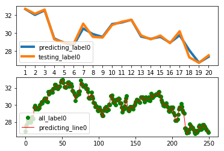

```
The best cross-validation score is: 9.195500915182622
The best parameter is: 4.82
Begin predicting on testing set!
Testing complete!
The score for testing set is: 0.8830887552818629
```

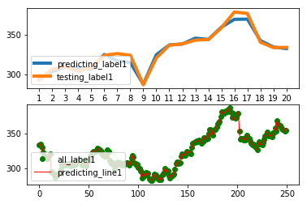

```
The best cross-validation score is: 0.6392723971434502
The best parameter is: 3.02
Begin predicting on testing set!
Testing complete!
The score for testing set is: 1.4148478109458265
```

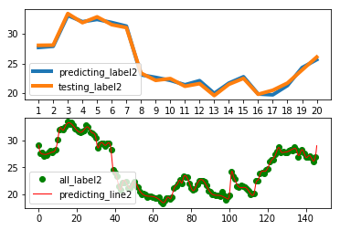

```
The best cross-validation score is: 1.8296129225771582
The best parameter is: 4.34
Begin predicting on testing set!
Testing complete!
The score for testing set is: 0.7951478546080573
```

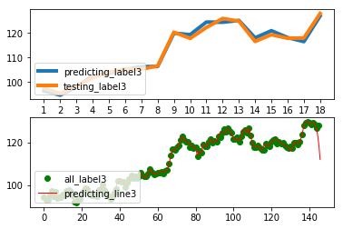

```
The best cross-validation score is: 0.2878290064575768
The best parameter is: 2.48
Begin predicting on testing set!
Testing complete!
The score for testing set is: 0.9180196773153627
```

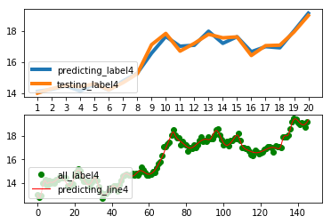

```
The best cross-validation score is: 0.24958392901879703
The best parameter is: 2.42
Begin predicting on testing set!
Testing complete!
The score for testing set is: 1.3563469404230086
```

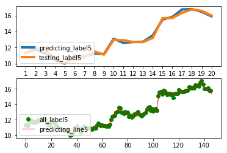

```
The best cross-validation score is: 0.38155645771085483
The best parameter is: 0.38
Begin predicting on testing set!
Testing complete!
The score for testing set is: 0.5382182828770821
```

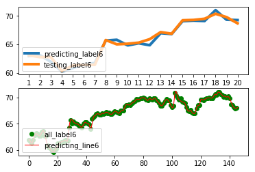

```
The best cross-validation score is: 0.37032182855398954
The best parameter is: 3.8
Begin predicting on testing set!
Testing complete!
The score for testing set is: 0.33365765513267265
```

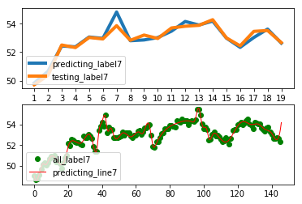

```
The best cross-validation score is: 0.19559786477906574
The best parameter is: 0.44
Begin predicting on testing set!
Testing complete!
The score for testing set is: 0.8679742823664903
```

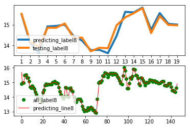

```
The best cross-validation score is: 0.25862077552729984
The best parameter is: 3.08
Begin predicting on testing set!
Testing complete!
The score for testing set is: 0.636903539291349
```

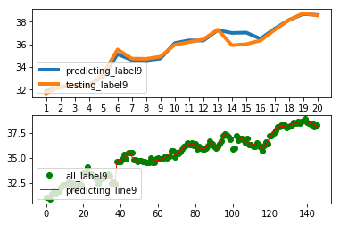

```python
# D is the average score for each case, N is the total number of missing labels (interpolation only) for each case. Note, for case 3, N is 18.
D0,N0 = Evaluate_spline_no_extra(training_feature0, training_label0, testing_feature0, testing_label0, total_label0,0)
D1,N1 = Evaluate_spline_no_extra(training_feature1, training_label1, testing_feature1, testing_label1, total_label1,1)
D2,N2 = Evaluate_spline_no_extra(training_feature2, training_label2, testing_feature2, testing_label2, total_label2,2)
D3,N3 = Evaluate_spline_no_extra(training_feature3, training_label3, testing_feature3, testing_label3, total_label3,3)
D4,N4 = Evaluate_spline_no_extra(training_feature4, training_label4, testing_feature4, testing_label4, total_label4,4)
D5,N5 = Evaluate_spline_no_extra(training_feature5, training_label5, testing_feature5, testing_label5, total_label5,5)
D6,N6 = Evaluate_spline_no_extra(training_feature6, training_label6, testing_feature6, testing_label6, total_label6,6)
D7,N7 = Evaluate_spline_no_extra(training_feature7, training_label7, testing_feature7, testing_label7, total_label7,7)
D8,N8 = Evaluate_spline_no_extra(training_feature8, training_label8, testing_feature8, testing_label8, total_label8,8)
D9,N9 = Evaluate_spline_no_extra(training_feature9, training_label9, testing_feature9, testing_label9, total_label9,9)
```

**We can see that for different cases, there are different optimal parameters S selected to minimize the mean differences.**

**Let's look at the final score for the interpolation data only. The score is 58.28, much higher than before!**

```python
d_tot_fitpack = (D0*N0+D1*N1+D2*N2+D3*N3+D4*N4+D5*N5+D6*N6+D7*N7+D8*N8+D9*N9)
d_avg_fitpack = d_tot_fitpack / (N0+N1+N2+N3+N4+N5+N6+N7+N8+N9 )
score = 50 * max(2 - d_avg_fitpack, 0)
print('The score is: {0}'.format(score))
```

```
The score is: 58.27708242026147
```

```python
dd0, nn0 = Evaluate_spline_interp1d(training_feature0, training_label0, testing_feature0, testing_label0, total_label0, 0, 0)
dd1, nn1 = Evaluate_spline_interp1d(training_feature1, training_label1, testing_feature1, testing_label1, total_label1,1,0)
dd2, nn2 = Evaluate_spline_interp1d(training_feature2, training_label2, testing_feature2, testing_label2, total_label2,2,0)
dd3, nn3 = Evaluate_spline_interp1d(training_feature3, training_label3, testing_feature3, testing_label3, total_label3,3,0)
dd4, nn4 = Evaluate_spline_interp1d(training_feature4, training_label4, testing_feature4, testing_label4, total_label4,4,0)
dd5, nn5 = Evaluate_spline_interp1d(training_feature5, training_label5, testing_feature5, testing_label5, total_label5,5,0)
dd6, nn6 = Evaluate_spline_interp1d(training_feature6, training_label6, testing_feature6, testing_label6, total_label6,6,0)
dd7, nn7 = Evaluate_spline_interp1d(training_feature7, training_label7, testing_feature7, testing_label7, total_label7,7,0)
dd8, nn8 = Evaluate_spline_interp1d(training_feature8, training_label8, testing_feature8, testing_label8, total_label8,8,0)
dd9, nn9 = Evaluate_spline_interp1d(training_feature9, training_label9, testing_feature9, testing_label9, total_label9,9,0)
```

**By using the interpolate.interp1d package, I also get a score of 53.98, but not as good as UnivariateSpline package (using FITPACK).**

**But for time efficiency, interp1d might seem better, although with lower accuracy.**

```python
d_tot = (dd0*nn0+dd1*nn1+dd2*nn2+dd3*nn3+dd4*nn4+dd5*nn5+dd6*nn6+dd7*nn7+dd8*nn8+dd9*nn9)
d_avg = d_tot / (nn0+nn1+nn2+nn3+nn4+nn5+nn6+nn7+nn8+nn9 )
score = 50 * max(2 - d_avg, 0)
print('The score is: {0}'.format(score))
```

```
The score is: 53.98366671868611
```

# Step 4: Sets of Piecewise Polynomial Interpolation Models

# Sets of Polynomial Regression Models

**Now let's deal with problem 3. Since a spline model is not suitable for extrapolating the missing data, I will try the polynomial regression instead. A polynomial model with lower degree might be suitable for predicting the outer data points.**

**Same as before, I use the random training-validation split to do the validation and find the optimal degree of order for each polynomial model.**

```python
def Evaluate_regression_extra(training_feature, training_label, total_label, testing_for_regression, number):

    d = -9999
    min_mse = 9999
    deg_opt = -2
    predicting_label = []

    if len(testing_for_regression.keys())==0:

        return d,0

    testing_feature = []
    testing_label = []

    for k,v in dict(sorted(testing_for_regression.items())).items():
        testing_feature.append(k)
        testing_label.append(v)



    x_train, x_test, y_train, y_test = train_test_split(training_feature, training_label, test_size=0.2, random_state=3)

    for deg in [6,7,8,9,10,11,12]:

        #model = make_pipeline(PolynomialFeatures(deg), Ridge())
        model = np.poly1d(np.polyfit(x_train, y_train, deg))
        #model.fit(np.reshape(x_train,(-1,1)), y_train)
        #y_predict = model.predict(np.reshape(x_test,(-1,1)))
        y_predict = model(x_test)
        mse = mean_squared_error(y_predict, y_test)
        if min_mse > mse:
            min_mse = mse
            deg_opt = deg

    print('The minimum validation MSE is: {0}'.format(min_mse))
    print('The best degree is: {0}'.format(deg_opt))
    print('Begin predicting on testing set!')

    #model = make_pipeline(PolynomialFeatures(deg_opt), Ridge())
    #model.fit(np.reshape(training_feature,(-1,1)), training_label)
    model = np.poly1d(np.polyfit(training_feature, training_label, deg))
    for each_feature in testing_feature:

        #predicting_label.append(model.predict(np.reshape(each_feature,(-1,1))))
        predicting_label.append(model(each_feature))
    d = 0

    for i in range(len(testing_feature)):
        d+=(abs(testing_label[i]-predicting_label[i])/testing_label[i])*100

    d/=len(testing_feature)

    print('Testing complete!')
    print('The score for testing set is: {0}'.format(d))


    n_1 = len(testing_feature)
    n_2 = len(total_label)

    x = np.arange(1,n_1+1,1)
    plt.subplot(2,1,1)
    plt.plot( x, predicting_label,'o', x, testing_label,'x')
    plt.legend(['predicting_label'+str(number), 'testing_label'+str(number)], loc='lower left')
    plt.xticks(np.arange(1, n_1+1, 1))

    i = np.linspace(0, n_2, num=500, endpoint=False)
    j = np.linspace(0, n_2, num=n_2, endpoint=False)
    plt.subplot(2,1,2)
    plt.plot( j, total_label,'go', i, model(i),'r', linewidth=1)
    plt.legend(['all_label'+str(number), 'predicting_line'+str(number)], loc='lower left')

    plt.show()

    return d, len(testing_feature)
```

**By looking at the comparison between predicted labels and testing labels during extrapolation, it is clear that the outer missing data that were not well predicted by spline models now are well predicted.**

```
The minimum validation MSE is: 7.123398921249565
The best degree is: 11
Begin predicting on testing set!
Testing complete!
The score for testing set is: 0.9501877211211591
```

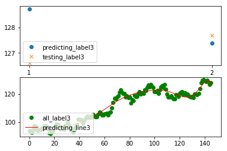

```
The minimum validation MSE is: 0.38974335378278546
The best degree is: 9
Begin predicting on testing set!
Testing complete!
The score for testing set is: 0.4929954673298824
```

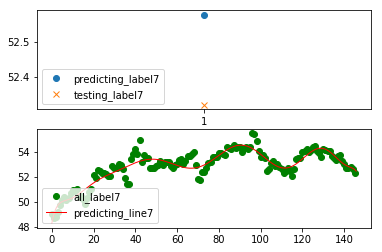

```
The minimum validation MSE is: 0.13554473743377754
The best degree is: 11
Begin predicting on testing set!
Testing complete!
The score for testing set is: 1.4901886747800428
```

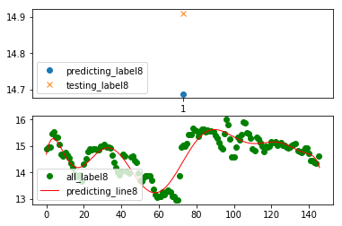

```python
# d is the average score for each case, n is the total number of missing labels (extrapolation only) for each case. Note, for case 3, n3 is 2.
d0, n0 = Evaluate_regression_extra(training_feature0, training_label0, total_label0, testing_for_regression0, 0)
d1, n1 = Evaluate_regression_extra(training_feature1, training_label1, total_label1, testing_for_regression1, 1)
d2, n2 = Evaluate_regression_extra(training_feature2, training_label2, total_label2, testing_for_regression2, 2)
d3, n3 = Evaluate_regression_extra(training_feature3, training_label3, total_label3, testing_for_regression3, 3)
d4, n4 = Evaluate_regression_extra(training_feature4, training_label4, total_label4, testing_for_regression4, 4)
d5, n5 = Evaluate_regression_extra(training_feature5, training_label5, total_label5, testing_for_regression5, 5)
d6, n6 = Evaluate_regression_extra(training_feature6, training_label6, total_label6, testing_for_regression6, 6)
d7, n7 = Evaluate_regression_extra(training_feature7, training_label7, total_label7, testing_for_regression7, 7)
d8, n8 = Evaluate_regression_extra(training_feature8, training_label8, total_label8, testing_for_regression8, 8)
d9, n9 = Evaluate_regression_extra(training_feature9, training_label9, total_label9, testing_for_regression9, 9)
```

```python
d_tot_final_fitpack = (D0*N0+D1*N1+D2*N2+D3*N3+D4*N4+D5*N5+D6*N6+D7*N7+D8*N8+D9*N9+d0*n0+d1*n1+d2*n2+d3*n3+d4*n4+d5*n5+d6*n6+d7*n7+d8*n8+d9*n9)
d_avg_final_fitpack = d_tot_final_fitpack / (N0+N1+N2+N3+N4+N5+N6+N7+N8+N9 + n0+n1+n2+n3+n4+n5+n6+n7+n8+n9)
final_score_fitpack = 50 * max(2 - d_avg_final_fitpack, 0)
print('The overall score after combining spline model (with FITPACK) and extrapolation model is: {0}'.format(final_score_fitpack))
```

```
The overall score after combining spline model (with FITPACK) and extrapolation model is: 58.14065087576819
```

```python
d_tot_final = (dd0*nn0+dd1*nn1+dd2*nn2+dd3*nn3+dd4*nn4+dd5*nn5+dd6*nn6+dd7*nn7+dd8*nn8+dd9*nn9+d0*n0+d1*n1+d2*n2+d3*n3+d4*n4+d5*n5+d6*n6+d7*n7+d8*n8+d9*n9)
d_avg_final = d_tot_final / (nn0+nn1+nn2+nn3+nn4+nn5+nn6+nn7+nn8+nn9 + n0+n1+n2+n3+n4+n5+n6+n7+n8+n9)
final_score = 50 * max(2 - d_avg_final, 0)
print('The overall score after combining spline model (without FITPACK) and extrapolation model is: {0}'.format(final_score))
```

```
The overall score after combining spline model (without FITPACK) and extrapolation model is: 53.93310348822433
```